# Autoregressive Moving Average (ARIMA) & Stationarity

Time series techniques that rely on lagged values (AR models) or past errors (MA models), or a combination of the two (ARMA) require the series to be Stationary. Since this assumption is critical to the use of these techniques, we will first examine the Stationarity assumption, then look at ways to make a non-stationary series stationary. Next, we will examine AR and MA processes.

## Stationarity

A stationary time-series is one whose mean, variance and autocovariance do not change over time. Stationarity is a high standard for a time-series to achieve, so in practice we are happy with a weakly stationary time-series. Formally, this is a series that has

- constant mean
- constant variance
- covariance between yt and yt-k depend only on the lag k, not time t

### Importance of Stationarity

Stationarity is required because

- AR (Autoregressive) and MA (Moving Average) models rely on past values and past errors
- Models assume that the underlying process generating the data has stable patterns over time

### Stationarity and ARIMA

I in ARIMA stands for Integrated which refers to Differencing - a technique to convert a non-stationary series to stationary.  
An ARIMA(p,d,q) model specification includes

- p: number of AR terms
- d: number of times data is differenced to achieve stationarity
- q: number of MA terms

```python
import pandas as pd
import numpy as np
import matplotlib.pyplot as plt
from statsmodels.tsa.stattools import adfuller, kpss
from statsmodels.graphics.tsaplots import plot_pacf, plot_acf
from statsmodels.tsa.stattools import acf, pacf
import warnings
warnings.filterwarnings('ignore')
```

### Test for Stationarity

Stationarity may be assessed by

- Visual inspection of time series: A series with a trend, seasonality, or changing variance is non-stationary
- Statistical Test: Augmented Dickey-Fuller (ADF) test. A significant p-value indicates Stationarity. [ADF](https://www.statsmodels.org/dev/generated/statsmodels.tsa.stattools.adfuller.html). adfuller() returns
  - test statistic
  - p-value
  - number of lags used
  - number of observations
- Alternative Statistical Test: KPSS Test. Unlike ADF, a non-significant p-value indicates stationarity
  - test statitistic
  - p-value
  - critical values

Most time series data tend to be non-stationary, as an observation at time t+1 is generally related to an observation at time t. On the other hand, random data is essentially pattern-free and should therefore be stationary.

#### ADF test

```python
np.random.seed(617)
random_series = np.random.randn(100)
adfuller(random_series)
```

```
(np.float64(-11.973698930462975),
 np.float64(3.8454557176778796e-22),
 0,
 99,
 {'1%': np.float64(-3.498198082189098),
  '5%': np.float64(-2.891208211860468),
  '10%': np.float64(-2.5825959973472097)},
 np.float64(256.93161091832064))
```

```python
np.random.seed(617)
random_gamma_series = np.random.gamma(1, 1, 100)
adfuller(random_gamma_series)
```

```
(np.float64(-11.367463523253724),
 np.float64(9.151716398225804e-21),
 0,
 99,
 {'1%': np.float64(-3.498198082189098),
  '5%': np.float64(-2.891208211860468),
  '10%': np.float64(-2.5825959973472097)},
 np.float64(303.45738830282335))
```

#### KPSS Test

```python
kpss(random_series)
```

```
(np.float64(0.18278066980866578),
 np.float64(0.1),
 8,
 {'10%': 0.347, '5%': 0.463, '2.5%': 0.574, '1%': 0.739})
```

```python
kpss(random_gamma_series)
```

```
(np.float64(0.10439912247454027),
 np.float64(0.1),
 4,
 {'10%': 0.347, '5%': 0.463, '2.5%': 0.574, '1%': 0.739})
```

### Airline Passenger Data

This dataset contains monthly air passenger counts for Ireland from 2010 to 2018. Our focus is on “international”, which is the number of international passengers in thousands.

```python
passengers = pd.read_csv('air_passengers.csv',
                 parse_dates = ['date'], date_format='%Y-%m-%d',
                 index_col='date')
passengers = passengers.loc[passengers.name =='Ireland',:]
passengers.columns = [col.lower() for col in passengers.columns]
passengers.head()
```

| date | name | total | domestic | international | total_os |
| --- | --- | --- | --- | --- | --- |
| 2010-01-01 | Ireland | 1488.034 | 30.502 | 1457.532 | 1522.530 |
| 2010-02-01 | Ireland | 1548.150 | 38.198 | 1509.952 | 1579.746 |
| 2010-03-01 | Ireland | 1865.279 | 44.373 | 1820.906 | 1898.331 |
| 2010-04-01 | Ireland | 1464.440 | 25.856 | 1438.584 | 1468.642 |
| 2010-05-01 | Ireland | 1968.408 | 29.101 | 1939.307 | 1963.063 |

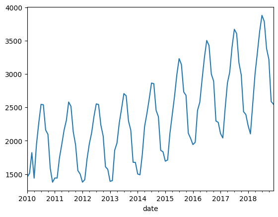

```python
passengers.international.plot()
plt.show()
```

##### ADF Test

```python
result = adfuller(passengers.international)
result
#result[0] # test statistic
#result[1] # p-value
```

```
(np.float64(1.643063266063003),
 np.float64(0.997981187440215),
 13,
 94,
 {'1%': np.float64(-3.5019123847798657),
  '5%': np.float64(-2.892815255482889),
  '10%': np.float64(-2.583453861475781)},
 np.float64(1108.9257517791186))
```

##### KPSS Test

```python
print('KPSS for Passengers', kpss(passengers.international))
print('-'*100)
print('KPSS for Random Data', kpss(np.random.randn(100)))
```

```
KPSS for Passengers (np.float64(1.2138185028650281), np.float64(0.01), 5, {'10%': 0.347, '5%': 0.463, '2.5%': 0.574, '1%': 0.739})
----------------------------------------------------------------------------------------------------
KPSS for Random Data (np.float64(0.12625211399090183), np.float64(0.1), 3, {'10%': 0.347, '5%': 0.463, '2.5%': 0.574, '1%': 0.739})
```

### Making Series Stationary

- Stabilize Variance
- Seasonal Differencing
- Lag Differencing

#### Stabilize Variance

- log transformation
- BoxCox transformation

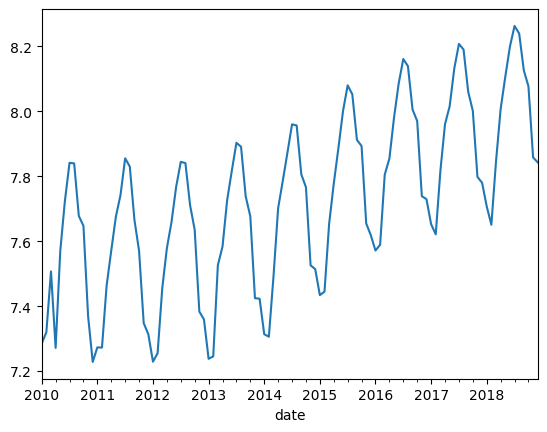

```python
passengers.loc[:,'log_international'] = np.log(passengers.international)
passengers.log_international.plot()
plt.show()
```

```python
from scipy.stats import boxcox
boxcox(passengers.international)[1] # Value of lambda to stabilize variance
```

```
np.float64(0.13317047390997858)
```

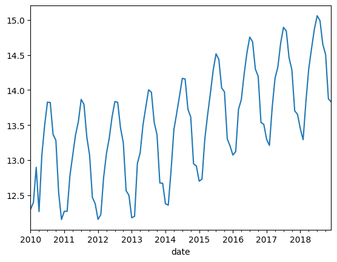

```python
passengers.loc[:,'boxcox_international'] = pd.Series(boxcox(passengers.international))[0]
passengers.boxcox_international.plot()
plt.show()
```

```python
print(adfuller(passengers.log_international))
print(adfuller(passengers.boxcox_international))
```

```
(np.float64(1.5586444795407652), np.float64(0.9977280461480141), 12, 95, {'1%': np.float64(-3.5011373281819504), '5%': np.float64(-2.8924800524857854), '10%': np.float64(-2.5832749307479226)}, np.float64(-319.97309105186764))
(np.float64(1.6646859551342137), np.float64(0.9980392280172474), 12, 95, {'1%': np.float64(-3.5011373281819504), '5%': np.float64(-2.8924800524857854), '10%': np.float64(-2.5832749307479226)}, np.float64(-132.10033095879317))
```

#### Seasonal Differencing

```python
passengers['seasonal_diff_international'] = passengers.international.diff(12)
```

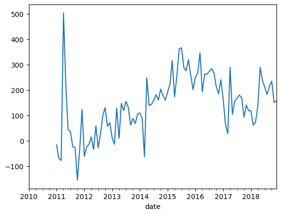

```python
passengers.seasonal_diff_international.plot()
plt.show()
```

```python
adfuller(passengers.seasonal_diff_international.dropna())
```

```
(np.float64(-1.8175192932711564),
 np.float64(0.37179919100943115),
 3,
 92,
 {'1%': np.float64(-3.503514579651927),
  '5%': np.float64(-2.893507960466837),
  '10%': np.float64(-2.583823615311909)},
 np.float64(935.4301203208896))
```

#### Lag Differencing

```python
passengers['diff_international'] = passengers.international.diff()
```

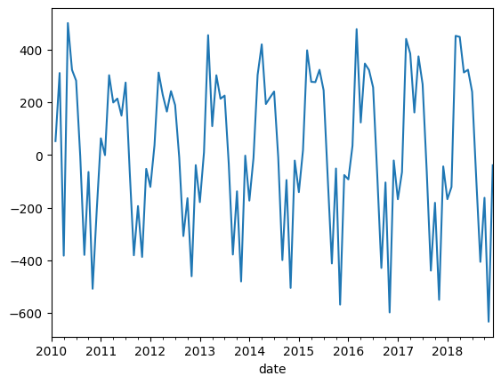

```python
passengers.diff_international.plot()
plt.show()
```

```python
adfuller(passengers.diff_international.dropna())
```

```
(np.float64(-2.1082937602500675),
 np.float64(0.24119274342845526),
 13,
 93,
 {'1%': np.float64(-3.502704609582561),
  '5%': np.float64(-2.8931578098779522),
  '10%': np.float64(-2.583636712914788)},
 np.float64(1090.904602214087))
```

#### Combine Transformations

```python
passengers['diff_seasonal_diff_boxcox_international'] = passengers.boxcox_international.diff(12).diff()
```

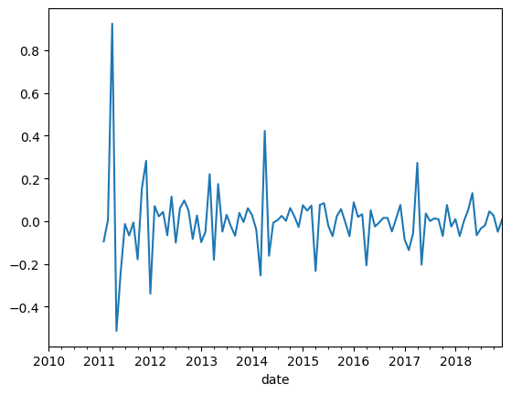

```python
passengers.diff_seasonal_diff_boxcox_international.plot()
plt.show()
```

```python
adfuller(passengers.diff_seasonal_diff_boxcox_international.dropna())
```

```
(np.float64(-12.268717095970251),
 np.float64(8.739380754463995e-23),
 2,
 92,
 {'1%': np.float64(-3.503514579651927),
  '5%': np.float64(-2.893507960466837),
  '10%': np.float64(-2.583823615311909)},
 np.float64(-177.36151025491552))
```

## nVidia Stock

This data contains daily stock price of nVidia from 2010 to 2024. The focus of this exercise is the closing price, labeled as “price”.

```python
nvidia = pd.read_csv('nvda.csv',
                parse_dates=['Date'],
                date_format ='%Y-%m-%d')
nvidia = nvidia.loc[:,['Close_NVDA','Date']]
nvidia.rename(columns= {'Close_NVDA': 'price',
                                'Date': 'date'}, inplace=True)
nvidia.set_index('date',inplace=True)
nvidia.head()
```

| date | price |
| --- | --- |
| 2010-01-04 | 0.423854 |
| 2010-01-05 | 0.430043 |
| 2010-01-06 | 0.432794 |
| 2010-01-07 | 0.424313 |
| 2010-01-08 | 0.425230 |

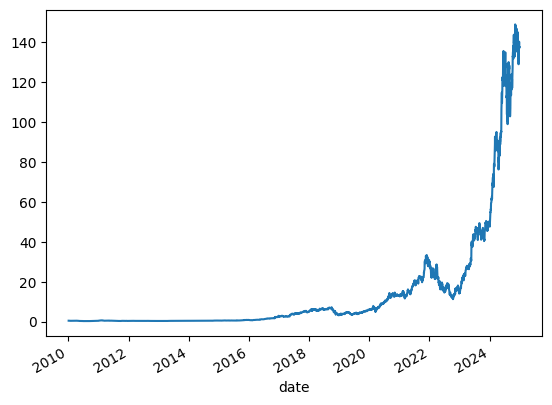

```python
nvidia.price.plot()
plt.show()
```

#### Stabilize Variance

With financial time series, log-transformation is the preferred method of stabilizing variance. This is because the log difference or log return approximates percent change.

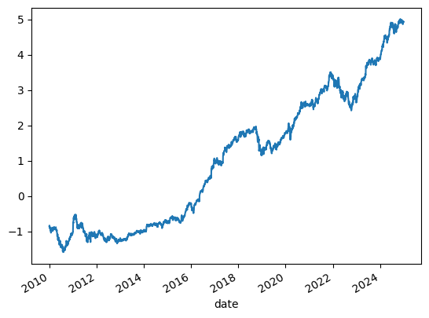

```python
nvidia['log_price'] = np.log(nvidia.price)
nvidia.log_price.plot()
plt.show()
```

#### Seasonal Differencing

nVidia’s stock price does not appear to have seasonality

#### Lag Differencing

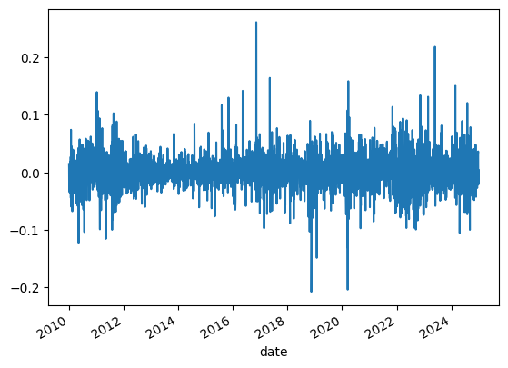

```python
nvidia['lag_log_price'] = nvidia.log_price.diff()
nvidia.lag_log_price.plot()
plt.show()
```

```python
adfuller(nvidia.lag_log_price.dropna())
```

```
(np.float64(-20.05599338488981),
 0.0,
 8,
 3763,
 {'1%': np.float64(-3.4320889759266966),
  '5%': np.float64(-2.8623083837347174),
  '10%': np.float64(-2.567179021121146)},
 np.float64(-16041.020499926304))
```

## Autoregressive (AR) Model

Forecast of a variable depends linearly on its own previous values. In other words, it is a regression of the variable against itself. Denoted as AR(p), where p is the number of lagged values.

Of course, not every series is an AR process, so we need a way to identify whether the series is following an AR process before trying to fit a model with lagged values.

- In a pure AR(p) process, the PACF drops sharply after lag p.
- The ACF tails off gradually.  
  E.g., if PACF has significant spikes at lags 1 and 2 only it suggests an AR(2) process

#### AR(1)

Let us simulate an AR(1) process and examine the corresponding PACF and ACF plots.

```python
ar1 = [0]
np.random.seed(617)
for i in range(1000):
  x = 0.5 * ar1[-1] + 0.1 * np.random.randn()
  ar1.append(x)
ar1 = np.array(ar1)
```

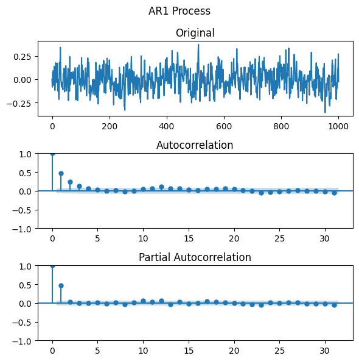

```python
fig, axes = plt.subplots(3, 1, figsize=(6, 6))
fig.suptitle('AR1 Process')
# Original data
axes[0].plot(ar1)
axes[0].set_title('Original')
plot_acf(ar1,ax=axes[1])
plot_pacf(ar1,ax=axes[2])
plt.tight_layout()
plt.show()
```

#### AR(2)

Next, we will simulate an AR(2) process. Compare and contrast the PACF plot with that of the AR(1) process.

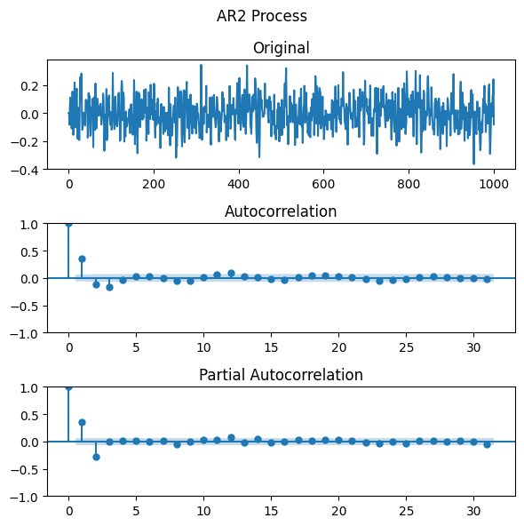

```python
ar2 = [0, 0]
np.random.seed(617)
for i in range(1000):
  x = 0.5 * ar2[-1] - 0.3*ar2[-2] + 0.1*np.random.randn()
  ar2.append(x)
ar2 = np.array(ar2)

fig, axes = plt.subplots(3, 1, figsize=(6, 6))
fig.suptitle('AR2 Process')
# Original data
axes[0].plot(ar2)
axes[0].set_title('Original')
plot_acf(ar2,ax=axes[1])
plot_pacf(ar2,ax=axes[2])
plt.tight_layout()
plt.show()
```

#### AR(5)

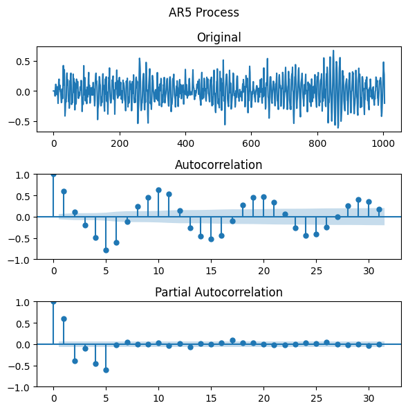

```python
ar5 = [0, 0, 0, 0, 0]
np.random.seed(617)
for i in range(1000):
  x = 0.5*ar5[-1] - 0.3*ar5[-2]  - 0.6*ar5[-5] + 0.1*np.random.randn()
  ar5.append(x)
ar5 = np.array(ar5)

fig, axes = plt.subplots(3, 1, figsize=(6, 6))
fig.suptitle('AR5 Process')
# Original data
axes[0].plot(ar5)
axes[0].set_title('Original')
plot_acf(ar5,ax=axes[1])
plot_pacf(ar5,ax=axes[2])
plt.tight_layout()
plt.show()
```

## Moving Average (MA) Model

Current value depends on current and past error terms. Denoted as MA(q)  
Modelled as linear combination of series mean (c), present error, and past errors. MA order, q, determines the number of past errors.

- In a pure MA(q) process, the ACF drops sharply after lag q.
- The PACF tails off gradually.
- E.g., if ACF has significant spikes at lags 1 and 2 only it suggests an MA(2) process.

#### MA(1)

```python
np.random.seed(617)
errors = 0.1 * np.random.randn(1000)
ma1 = []
for i in range(1000):
  if i >= 1:
    x = 0.5 + errors[i-1] + errors[i]
  else:
    x =  errors[i]
  ma1.append(x)
ma1 = np.array(ma1)
```

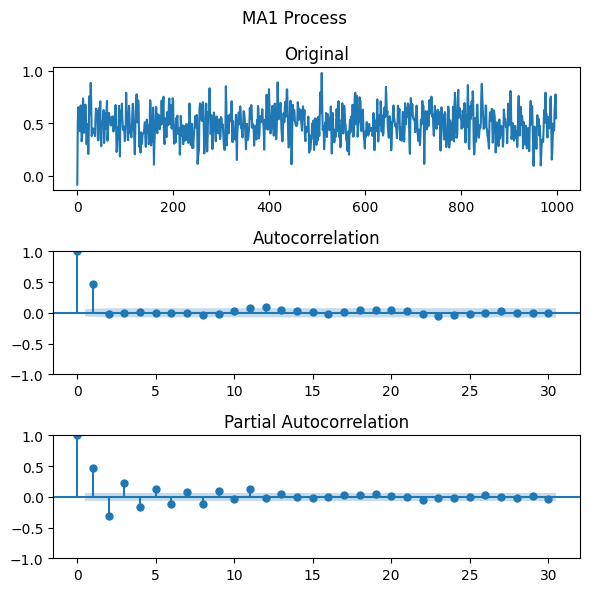

```python
fig, axes = plt.subplots(3, 1, figsize=(6, 6))
fig.suptitle('MA1 Process')
# Original data
axes[0].plot(ma1)
axes[0].set_title('Original')
plot_acf(ma1,ax=axes[1])
plot_pacf(ma1,ax=axes[2])
plt.tight_layout()
plt.show()
```

#### MA(2)

```python
np.random.seed(617)
errors = 0.1 * np.random.randn(1000)
ma2 = []
for i in range(1000):
  x = 0.5 + errors[i-1]  -0.3*errors[i-2] + errors[i]
  ma2.append(x)
ma2 = np.array(ma2)
```

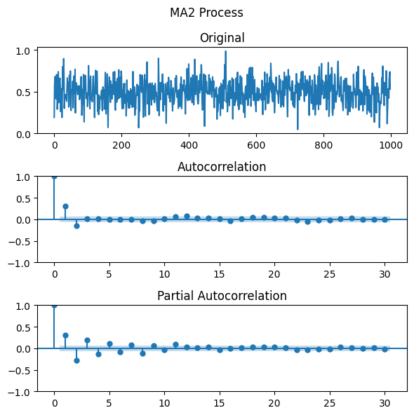

```python
fig, axes = plt.subplots(3, 1, figsize=(6, 6))
fig.suptitle('MA2 Process')
# Original data
axes[0].plot(ma2)
axes[0].set_title('Original')
plot_acf(ma2,ax=axes[1])
plot_pacf(ma2,ax=axes[2])
plt.tight_layout()
plt.show()
```

#### MA(6)

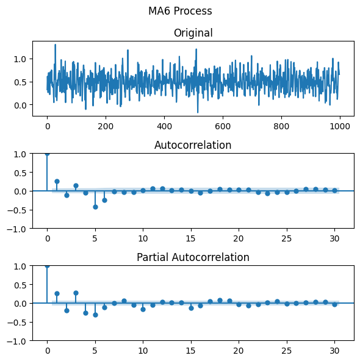

```python
np.random.seed(617)
errors = 0.1 * np.random.randn(1000)
ma6 = []
for i in range(1000):
  x = 0.5 + errors[i-1] - 0.3*errors[i-2] + 0.7*errors[i-3] + 0.2*errors[i-4] - 0.8*errors[i-5] - 0.9*errors[i-6] + errors[i]
  ma6.append(x)
ma6 = np.array(ma6)

fig, axes = plt.subplots(3, 1, figsize=(6, 6))
fig.suptitle('MA6 Process')
# Original data
axes[0].plot(ma6)
axes[0].set_title('Original')
plot_acf(ma6,ax=axes[1])
plot_pacf(ma6,ax=axes[2])
plt.tight_layout()
plt.show()
```

## Autoregressive Moving Average (ARMA)

ARMA is a combination of AR and MA. When both AR and MA terms are present, neither ACF nor PACF show a clear cut-off. Instead, both tail off gradually. In such cases, it is difficult to determine orders p and q from PACF and ACF plots. But, these plots may still offer hints or guidance on values of p and q that may be good.

Let us simulate an ARMA model and examine ACF and PACF plots.

#### ARMA (2,2)

```python
import numpy as np
np.random.seed(617)
n = 1000
errors = 0.1 * np.random.randn(n)
arma22 = []
for i in range(n):
    e0 = errors[i]
    e1 = errors[i-1] if i-1 >= 0 else 0
    e2 = errors[i-2] if i-2 >= 0 else 0
    if i < 2:
        x = e0 + 0.5*e1 - 0.3*e2
    else:
        x = 0.6*arma22[i-1] - 0.3*arma22[i-2] + e0 + 0.5*e1 - 0.3*e2
    arma22.append(x)
arma22 = np.array(arma22)
```

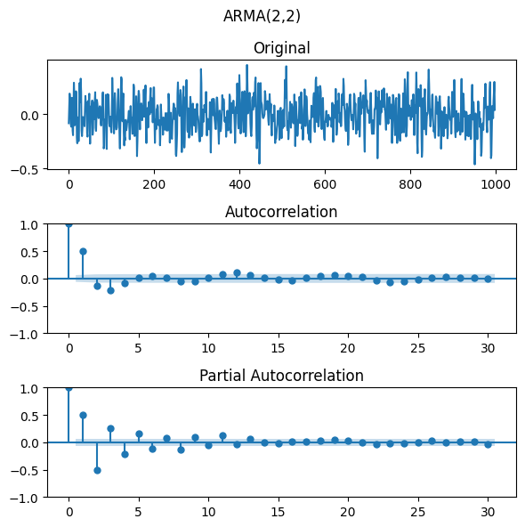

```python
fig, axes = plt.subplots(3, 1, figsize=(6, 6))
fig.suptitle('ARMA(2,2)')
# Original data
axes[0].plot(arma22)
axes[0].set_title('Original')
plot_acf(arma22,ax=axes[1])
plot_pacf(arma22,ax=axes[2])
plt.tight_layout()
plt.show()
```

#### ARMA (3,1)

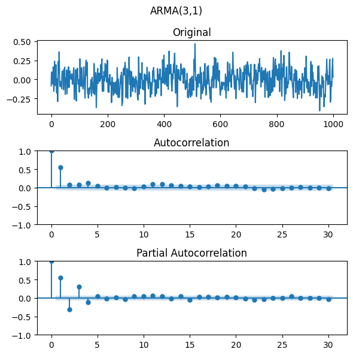

```python
import numpy as np
np.random.seed(617)
n = 1000
errors = 0.1 * np.random.randn(n)

# ARMA(3,1): X_t = 0.5*X_{t-1} - 0.3*X_{t-2} + 0.2*X_{t-3} + e_t + 0.4*e_{t-1}
arma31 = []
for i in range(n):
    e0 = errors[i]
    e1 = errors[i-1] if i-1 >= 0 else 0
    if i < 3:
        # for first few terms, just rely on available values
        x = e0 + 0.4*e1
    else:
        x = (0.5*arma31[i-1] - 0.3*arma31[i-2] + 0.2*arma31[i-3] +
             e0 + 0.4*e1)
    arma31.append(x)

arma31 = np.array(arma31)

fig, axes = plt.subplots(3, 1, figsize=(6, 6))
fig.suptitle('ARMA(3,1)')
# Original data
axes[0].plot(arma31)
axes[0].set_title('Original')
plot_acf(arma31,ax=axes[1])
plot_pacf(arma31,ax=axes[2])
plt.tight_layout()
plt.show()
```

## Summary

In this note, we examined stationarity, the assumption underlying most time-series models. Next, we examined methods to identify the order of AR and MA models from ACF and PACF plots.

This file was generated using Python 3.13.5 on Windows 10 with the following libraries: matplotlib 3.10.3, numpy 2.3.1, pandas 2.3.0, scipy 1.16.0, statsmodels 0.14.5